# Introdução às Estimativas

## 🎓 Introdução

Uma das principais aplicações da estatística é estimar parâmetros populacionais a partir de estatísticas amostrais.

Por exemplo, uma pesquisa pode tentar estimar a proporção de moradores adultos de uma cidade que apoiam uma proposta para construir um novo estádio esportivo.

De uma amostra aleatória de 200 pessoas, 106 dizem que apoiam a proposta.

Assim, na amostra, 0,53 das pessoas apoiaram a proposta. Esse valor de 0,53 é chamado de estimativa pontual da proporção populacional. É chamado de estimativa pontual porque a estimativa consiste em um único valor ou ponto.

As estimativas pontuais são geralmente complementadas por estimativas de intervalo chamadas intervalos de confiança.

Os intervalos de confiança são intervalos construídos usando um método que contém o parâmetro populacional em uma proporção especificada do tempo. Por exemplo, se o pesquisador usasse um método que contém o parâmetro 95% do tempo em que é usado, ele ou ela chegaria ao seguinte intervalo de confiança de 95%: 0,46<π<0,60. O pesquisador concluiria então que algo entre 0,46 e 0,60 da população apoia a proposta. A mídia geralmente relata esse tipo de resultado dizendo que 53% são a favor da proposta com uma margem de erro de 7%.

Em um experimento sobre memória para posições de xadrez, a recordação média para jogadores de torneio foi de 63,8 e a média para não jogadores foi de 33,1. Portanto, uma estimativa pontual da diferença entre as médias da população é de 30,7. O intervalo de confiança de 95% na diferença entre as médias se estende de 19,05 a 42,35. Você verá como calcular esse tipo de intervalo em breve.

## 💡 Estimadores

Estimadores são funções de amostras usadas para inferir características da população, como média, variância ou proporção. Eles são usados quando temos apenas uma amostra e queremos obter informações sobre a população inteira.

## 💡 Características dos Estimadores

✅ Viés: A média das estimativas deve estar centrada no valor verdadeiro.

✅ Consistência: Aumentar o tamanho da amostra faz a estimativa se aproximar do valor real.

✅ Eficiência: Menor variância entre todos os estimadores não viesados.

✅ Suficiência: Usa toda a informação da amostra para estimar o parâmetro.

✅ Robustez: Pouca sensibilidade a valores extremos.

✅ Intervalo de Confiança: Margem de erro da estimativa.

✅ Erro Padrão: Variabilidade da média amostral.

## 🎯 Viés

Um estimador é considerado viésado se o valor médio do estimador (em repetidas amostras) não coincide com o parâmetro populacional que ele está estimando.

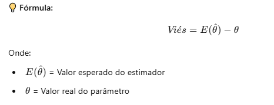

Exemplo: Um exemplo comum é a variância amostral, onde usamos 𝑛 − 1 no denominador (Grau de liberdade, a ser visto na próxima aula) para corrigir o viés e garantir que a estimativa seja não viesada.

## 🚀 Variabilidade Amostral (Sampling Variability)

Refere-se ao quanto os valores do estimador variam de uma amostra para outra. A variabilidade é medida pelo erro padrão.

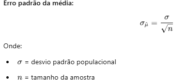

Quanto maior a amostra, menor o erro padrão e menor a variabilidade amostral.

Um estimador é consistente se ele se aproxima do valor verdadeiro do parâmetro conforme o tamanho da amostra aumenta.

Formalmente:

- À medida que o tamanho da amostra ( n) tende ao infinito, a estimativa se aproxima do parâmetro populacional.
- A variância do estimador tende a zero quando o tamanho da amostra aumenta.

Exemplo: A média amostral é um estimador consistente da média populacional, pois quanto maior a amostra, mais próxima a média amostral fica da média real.

## 📏 Valor Esperado (Expected Value)

O valor esperado é sinônimo de esperança matemática ou simplesmente média teórica de uma variável aleatória. Ele representa o valor médio que esperamos obter após um grande número de experimentos ou observações.

- É um conceito central na teoria das probabilidades e na estatística inferencial.
- Ele representa o valor médio que obteríamos se repetíssemos um experimento um grande número de vezes.
- No contexto de estimadores, o valor esperado de um estimador é usado para verificar se ele é não viesado (ou seja, se ele converge para o valor verdadeiro do parâmetro).

## 🏆 Eficiência Relativa (Relative Efficiency)

A eficiência relativa compara a precisão de dois estimadores. Um estimador é mais eficiente se tiver um menor erro padrão em comparação com outro.

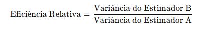

Se o valor for maior que 1, o estimador A é mais eficiente do que o estimador B.

## 💪 Robustez

Um estimador é robusto se ele não for muito sensível a valores extremos (outliers) ou a pequenas violações das premissas.

Exemplos de Estimadores Robustos:

- Mediana: Muito robusta contra outliers.
- Média Podada (Trimmed Mean): Calculada descartando uma proporção dos valores mais altos e mais baixos.

## 🧠 Suficiência

Um estimador é suficiente se ele utilizar toda a informação presente na amostra sobre o parâmetro que está sendo estimado.

Exemplo: A média amostral é um estimador suficiente para a média populacional em uma distribuição normal, pois captura todas as informações relevantes sobre o parâmetro.

## 🔍 Intervalo de Confiança

O intervalo de confiança dá uma margem de erro para estimativas, indicando o quanto podemos confiar no valor obtido. Será discutido posteriormente.